# Study on Policy & Research: Jan 2025

## データ

#### 回答に使用されたデバイス：

| Var1 | Freq |
| --- | --- |
| PC | 387 |
| Tablet | 17 |
| Smartphone | 369 |
| Other | 0 |

#### 性別：

| Var1 | Freq |
| --- | --- |
| Male | 381 |
| Female | 387 |
| Other | 1 |
| Prefer not to say | 4 |

#### 年齢：

|  | vars | n | mean | sd | median | trimmed | mad | min | max | range | skew | kurtosis | se |
| --- | --- | --- | --- | --- | --- | --- | --- | --- | --- | --- | --- | --- | --- |
| X1 | 1 | 763 | 42.9 | 10.8 | 43 | 42.6 | 11.9 | 19 | 78 | 59 | 0.323 | -0.199 | 0.392 |

### 変数合成

#### シナリオに対する印象

##### 探索的因子分析：研究の一般化可能性／重要性

因子分析の結果、エビデンスありなし両条件で2因子が抽出された.  
研究結果の実用性評価（gen）と重要性評価（sig）は概ね想定通りに分かれたが、重要性評価の一項目（sig2「実社会に応用できそうな示唆がある」）のみ一般化可能性因子への寄与がみられたため、当該項目は実用性のほうに含めて変数を合成した。.  
実用性評価（5項目α、エビデンスあり条件で0.79、エビデンスなし条件で0.845）と重要性評価（3項目α、エビデンスあり条件で0.746、エビデンスなし条件で0.809）の平均値をもとに得点化した。

###### 因子分析結果：エビデンスあり

```
## [1] 3.855 0.968 0.765 0.587 0.528 0.510 0.440 0.348
```

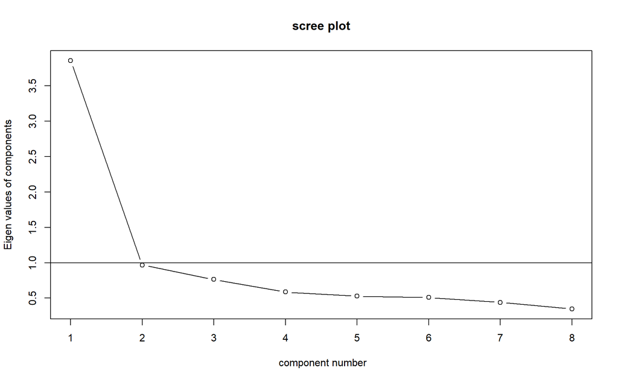

|  | ML2 | ML1 |
| --- | --- | --- |
| gen2 | 0.764 | -0.112 |
| gen3 | 0.669 | -0.005 |
| gen4 | 0.623 | -0.009 |
| gen1 | 0.512 | 0.173 |
| sig2 | 0.484 | 0.282 |
| sig1 | -0.065 | 0.894 |
| sig4 | -0.065 | 0.708 |
| sig3 | 0.230 | 0.474 |

###### 因子分析結果：エビデンスなし

```
## [1] 4.336 1.046 0.646 0.494 0.446 0.395 0.371 0.267
```

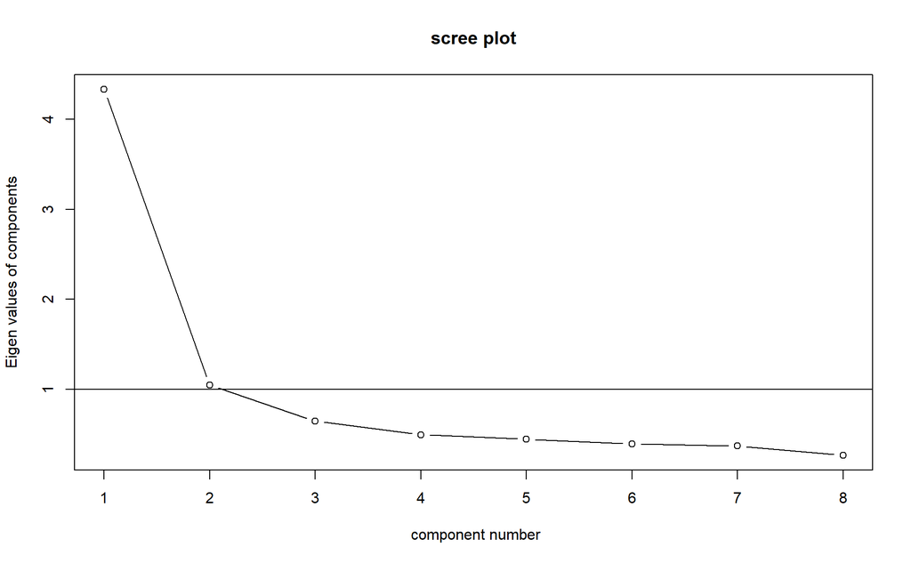

|  | ML2 | ML1 |
| --- | --- | --- |
| gen3 | 0.819 | -0.134 |
| gen1 | 0.763 | 0.027 |
| gen4 | 0.692 | 0.060 |
| gen2 | 0.676 | -0.040 |
| sig2 | 0.618 | 0.172 |
| sig1 | -0.123 | 1.039 |
| sig4 | 0.001 | 0.713 |
| sig3 | 0.399 | 0.405 |

#### 探索的因子分析：政策的議論に対する態度

因子分析の結果、2因子が抽出された。研究を政策に活用することへのポジティブな認知とリスクの認知に分かれたと判断できる。ポジティブ認知（pos; 4項目α = 0.799）とリスク認知（risk; 6項目α = 0.891）の平均値をもとに得点化した。

###### Eigenvalues

```
##  [1] 5.307 1.409 0.673 0.568 0.486 0.384 0.334 0.327 0.264 0.248
```

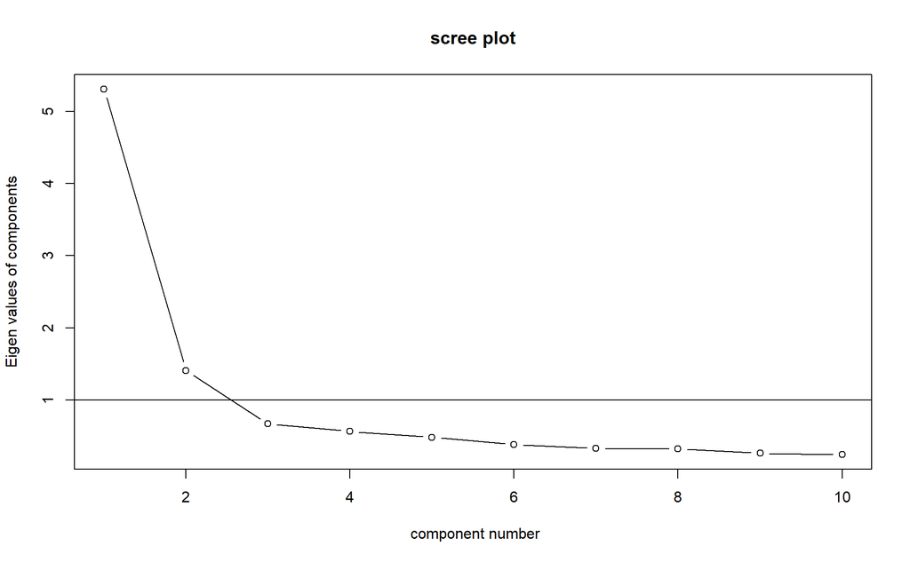

###### Factor loading

|  | ML1 | ML2 |
| --- | --- | --- |
| eval6 | 0.862 | 0.044 |
| eval7 | 0.856 | 0.098 |
| eval4 | 0.770 | -0.158 |
| eval5 | 0.767 | -0.090 |
| eval8 | 0.674 | 0.121 |
| eval10 | 0.630 | -0.017 |
| eval9 | -0.133 | 0.664 |
| eval1 | 0.242 | 0.644 |
| eval2 | -0.283 | 0.642 |
| eval3 | -0.371 | 0.571 |

#### 探索的因子分析：社会科学諸領域への態度

##### 社会心理学への態度

###### Eigenvalues

```
## [1] 4.131 1.054 0.857 0.679 0.567 0.554 0.468 0.372 0.318
```

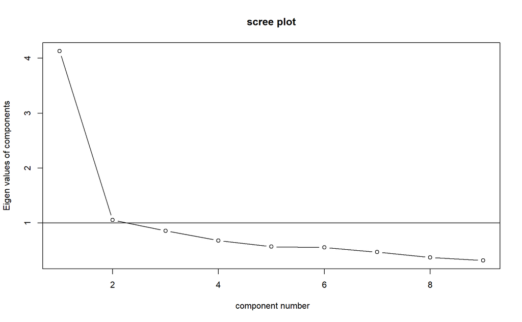

###### Factor loading

|  | ML1 | ML2 |
| --- | --- | --- |
| socpsy_1 | 0.816 | -0.051 |
| socpsy_6 | 0.766 | -0.011 |
| socpsy_7 | 0.687 | -0.010 |
| socpsy_9 | 0.607 | 0.105 |
| socpsy_8 | -0.464 | 0.034 |
| socpsy_5 | -0.456 | -0.006 |
| socpsy_3 | 0.433 | 0.255 |
| socpsy_4 | -0.087 | 0.882 |
| socpsy_2 | 0.050 | 0.780 |

##### 行動経済学への態度

###### Eigenvalues

```
## [1] 4.302 1.143 0.922 0.615 0.582 0.468 0.405 0.322 0.241
```

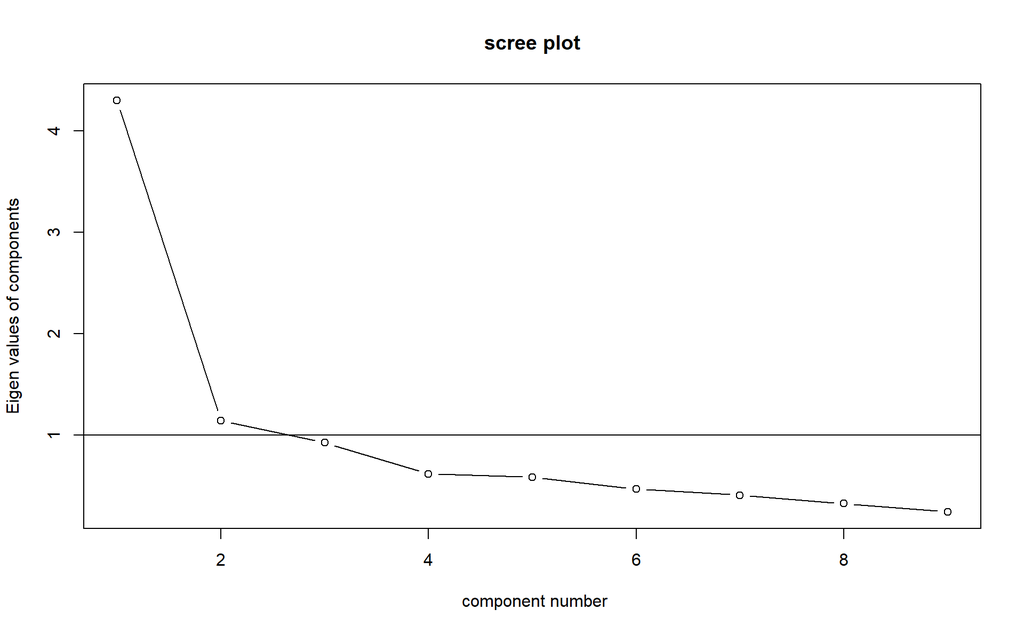

###### Factor loading

|  | ML2 | ML1 |
| --- | --- | --- |
| behavecon_6 | 0.943 | -0.167 |
| behavecon_7 | 0.800 | -0.150 |
| behavecon_1 | 0.698 | 0.080 |
| behavecon_9 | 0.583 | 0.174 |
| behavecon_5 | -0.419 | -0.112 |
| behavecon_8 | -0.385 | -0.062 |
| behavecon_2 | -0.090 | 0.956 |
| behavecon_4 | -0.088 | 0.887 |
| behavecon_3 | 0.310 | 0.421 |

##### 政策科学への態度

###### Eigenvalues

```
## [1] 4.735 1.014 0.837 0.587 0.543 0.391 0.361 0.310 0.224
```

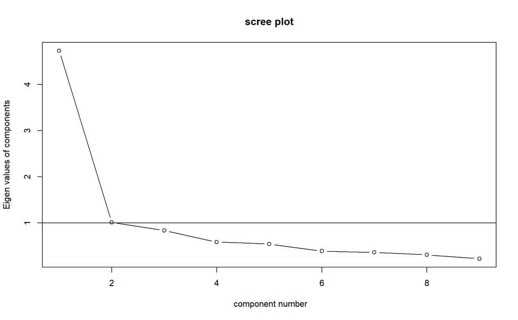

###### Factor loading

|  | ML2 | ML1 |
| --- | --- | --- |
| polisci_6 | 0.906 | -0.083 |
| polisci_1 | 0.771 | 0.046 |
| polisci_7 | 0.743 | -0.081 |
| polisci_9 | 0.615 | 0.130 |
| polisci_3 | 0.497 | 0.319 |
| polisci_5 | -0.447 | -0.144 |
| polisci_8 | -0.290 | -0.015 |
| polisci_4 | -0.041 | 0.897 |
| polisci_2 | -0.005 | 0.894 |

#### その他の変数

##### 信頼性

Mean scores were calculated to create composite variables for:

* EBPMへの態度 (ebpm1, ebpm2; r = 0.765)

* 政府・自治体への信頼の知覚 (trust_gvt5, trust_gvt6; r = 0.789)  
* 政府・自治体への誠実さの認知 (trust_gvt2, trust_gvt3, trust_gvt4; r = 0.907)  
* 研究者への信頼の知覚 (trust_rsch5, trust_rsch6; r = 0.708)  
* 研究者への誠実さの認知 (trust_rsch2, trust_rsch3, trust_rsch4; r = 0.828)

* TIPI-J (外向性 r = 0.528、協調性 r = 0.448、勤勉性 r = 0.65、神経症傾向 r = 0.564、開放性 r = 0.529)

### Descriptive statistics

##### (Distributions: not included in output)

#### Correlations: All conditions

|  | gen | sig | pos | risk | ebpm | trst_gvt | fair_gvt | comp_gvt | valu_gvt | trst_rsch | fair_rsch | comp_rsch | valu_rsch | sci_psyc | pos_psyc | sci_econ | pos_econ | sci_poli | pos_poli |
| --- | --- | --- | --- | --- | --- | --- | --- | --- | --- | --- | --- | --- | --- | --- | --- | --- | --- | --- | --- |
| gen | 1 |  |  |  |  |  |  |  |  |  |  |  |  |  |  |  |  |  |  |
| sig | 0.63 | 1 |  |  |  |  |  |  |  |  |  |  |  |  |  |  |  |  |  |
| pos | 0.53 | 0.67 | 1 |  |  |  |  |  |  |  |  |  |  |  |  |  |  |  |  |
| risk | -0.18 | -0.3 | -0.59 | 1 |  |  |  |  |  |  |  |  |  |  |  |  |  |  |  |
| ebpm | 0.22 | 0.22 | 0.2 | -0.02 | 1 |  |  |  |  |  |  |  |  |  |  |  |  |  |  |
| trst_gvt | 0.1 | 0.15 | 0.21 | -0.21 | -0.09 | 1 |  |  |  |  |  |  |  |  |  |  |  |  |  |
| fair_gvt | 0.08 | 0.16 | 0.21 | -0.2 | -0.08 | 0.83 | 1 |  |  |  |  |  |  |  |  |  |  |  |  |
| comp_gvt | 0.06 | 0.1 | 0.15 | -0.13 | -0.09 | 0.58 | 0.65 | 1 |  |  |  |  |  |  |  |  |  |  |  |
| valu_gvt | 0.04 | 0.1 | 0.19 | -0.17 | -0.11 | 0.62 | 0.63 | 0.48 | 1 |  |  |  |  |  |  |  |  |  |  |
| trst_rsch | 0.26 | 0.27 | 0.3 | -0.17 | 0.13 | 0.13 | 0.12 | 0.08 | 0.06 | 1 |  |  |  |  |  |  |  |  |  |
| fair_rsch | 0.25 | 0.27 | 0.28 | -0.12 | 0.13 | 0.14 | 0.17 | 0.13 | 0.06 | 0.78 | 1 |  |  |  |  |  |  |  |  |
| comp_rsch | 0.27 | 0.25 | 0.2 | -0.09 | 0.21 | 0.08 | 0.07 | 0.12 | -0.03 | 0.58 | 0.58 | 1 |  |  |  |  |  |  |  |
| valu_rsch | 0.14 | 0.23 | 0.28 | -0.15 | 0.1 | 0.11 | 0.15 | 0.07 | 0.22 | 0.42 | 0.38 | 0.19 | 1 |  |  |  |  |  |  |
| sci_psyc | 0.22 | 0.25 | 0.23 | -0.09 | 0.2 | 0.1 | 0.12 | 0.1 | 0.05 | 0.24 | 0.27 | 0.21 | 0.15 | 1 |  |  |  |  |  |
| pos_psyc | 0.34 | 0.36 | 0.36 | -0.18 | 0.16 | 0.12 | 0.13 | 0.08 | 0.03 | 0.45 | 0.46 | 0.34 | 0.29 | 0.54 | 1 |  |  |  |  |
| sci_econ | 0.15 | 0.13 | 0.11 | -0.02 | 0.15 | 0.1 | 0.12 | 0.07 | 0.04 | 0.17 | 0.2 | 0.1 | 0.16 | 0.58 | 0.4 | 1 |  |  |  |
| pos_econ | 0.32 | 0.31 | 0.27 | -0.12 | 0.15 | 0.08 | 0.1 | 0.05 | 0.01 | 0.44 | 0.42 | 0.3 | 0.26 | 0.44 | 0.71 | 0.56 | 1 |  |  |
| sci_poli | 0.17 | 0.16 | 0.14 | -0.07 | 0.1 | 0.2 | 0.18 | 0.15 | 0.13 | 0.22 | 0.24 | 0.17 | 0.14 | 0.37 | 0.37 | 0.39 | 0.37 | 1 |  |
| pos_poli | 0.27 | 0.25 | 0.25 | -0.12 | 0.12 | 0.25 | 0.25 | 0.2 | 0.1 | 0.39 | 0.38 | 0.28 | 0.2 | 0.32 | 0.56 | 0.3 | 0.54 | 0.66 | 1 |

#### Correlations: Evidence-present condition

|  | gen | sig | pos | risk | ebpm | trst_gvt | fair_gvt | comp_gvt | valu_gvt | trst_rsch | fair_rsch | comp_rsch | valu_rsch | sci_psyc | pos_psyc | sci_econ | pos_econ | sci_poli | pos_poli |
| --- | --- | --- | --- | --- | --- | --- | --- | --- | --- | --- | --- | --- | --- | --- | --- | --- | --- | --- | --- |
| gen | 1 |  |  |  |  |  |  |  |  |  |  |  |  |  |  |  |  |  |  |
| sig | 0.61 | 1 |  |  |  |  |  |  |  |  |  |  |  |  |  |  |  |  |  |
| pos | 0.42 | 0.61 | 1 |  |  |  |  |  |  |  |  |  |  |  |  |  |  |  |  |
| risk | -0.03 | -0.22 | -0.54 | 1 |  |  |  |  |  |  |  |  |  |  |  |  |  |  |  |
| ebpm | 0.19 | 0.2 | 0.25 | 0 | 1 |  |  |  |  |  |  |  |  |  |  |  |  |  |  |
| trst_gvt | 0.05 | 0.17 | 0.15 | -0.17 | -0.07 | 1 |  |  |  |  |  |  |  |  |  |  |  |  |  |
| fair_gvt | 0.06 | 0.2 | 0.21 | -0.21 | -0.09 | 0.84 | 1 |  |  |  |  |  |  |  |  |  |  |  |  |
| comp_gvt | 0.05 | 0.11 | 0.11 | -0.11 | -0.07 | 0.6 | 0.67 | 1 |  |  |  |  |  |  |  |  |  |  |  |
| valu_gvt | 0.04 | 0.1 | 0.16 | -0.15 | -0.1 | 0.66 | 0.68 | 0.55 | 1 |  |  |  |  |  |  |  |  |  |  |
| trst_rsch | 0.3 | 0.33 | 0.35 | -0.18 | 0.12 | 0.13 | 0.11 | 0.04 | 0.09 | 1 |  |  |  |  |  |  |  |  |  |
| fair_rsch | 0.3 | 0.35 | 0.32 | -0.1 | 0.17 | 0.12 | 0.17 | 0.1 | 0.11 | 0.77 | 1 |  |  |  |  |  |  |  |  |
| comp_rsch | 0.29 | 0.3 | 0.17 | -0.06 | 0.23 | 0.08 | 0.05 | 0.08 | -0.01 | 0.6 | 0.58 | 1 |  |  |  |  |  |  |  |
| valu_rsch | 0.14 | 0.29 | 0.36 | -0.2 | 0.08 | 0.14 | 0.21 | 0.1 | 0.25 | 0.39 | 0.42 | 0.18 | 1 |  |  |  |  |  |  |
| sci_psyc | 0.3 | 0.27 | 0.23 | -0.09 | 0.21 | 0.06 | 0.11 | 0.05 | 0.07 | 0.29 | 0.32 | 0.27 | 0.14 | 1 |  |  |  |  |  |
| pos_psyc | 0.44 | 0.42 | 0.44 | -0.23 | 0.18 | 0.14 | 0.17 | 0.1 | 0.12 | 0.48 | 0.5 | 0.38 | 0.29 | 0.56 | 1 |  |  |  |  |
| sci_econ | 0.22 | 0.21 | 0.13 | 0.02 | 0.15 | 0.08 | 0.09 | 0.01 | 0.07 | 0.24 | 0.28 | 0.13 | 0.18 | 0.61 | 0.44 | 1 |  |  |  |
| pos_econ | 0.36 | 0.35 | 0.31 | -0.14 | 0.19 | 0.08 | 0.1 | 0.07 | 0.07 | 0.46 | 0.44 | 0.34 | 0.25 | 0.45 | 0.72 | 0.59 | 1 |  |  |
| sci_poli | 0.24 | 0.25 | 0.18 | -0.14 | 0.11 | 0.17 | 0.19 | 0.14 | 0.15 | 0.26 | 0.27 | 0.19 | 0.18 | 0.41 | 0.42 | 0.43 | 0.44 | 1 |  |
| pos_poli | 0.29 | 0.35 | 0.31 | -0.2 | 0.13 | 0.25 | 0.3 | 0.22 | 0.21 | 0.41 | 0.42 | 0.27 | 0.22 | 0.38 | 0.6 | 0.41 | 0.59 | 0.71 | 1 |

#### Correlations: No-evidence condition

|  | gen | sig | pos | risk | ebpm | trst_gvt | fair_gvt | comp_gvt | valu_gvt | trst_rsch | fair_rsch | comp_rsch | valu_rsch | sci_psyc | pos_psyc | sci_econ | pos_econ | sci_poli | pos_poli |
| --- | --- | --- | --- | --- | --- | --- | --- | --- | --- | --- | --- | --- | --- | --- | --- | --- | --- | --- | --- |
| gen | 1 |  |  |  |  |  |  |  |  |  |  |  |  |  |  |  |  |  |  |
| sig | 0.63 | 1 |  |  |  |  |  |  |  |  |  |  |  |  |  |  |  |  |  |
| pos | 0.6 | 0.71 | 1 |  |  |  |  |  |  |  |  |  |  |  |  |  |  |  |  |
| risk | -0.3 | -0.37 | -0.63 | 1 |  |  |  |  |  |  |  |  |  |  |  |  |  |  |  |
| ebpm | 0.27 | 0.25 | 0.18 | -0.04 | 1 |  |  |  |  |  |  |  |  |  |  |  |  |  |  |
| trst_gvt | 0.16 | 0.15 | 0.27 | -0.25 | -0.11 | 1 |  |  |  |  |  |  |  |  |  |  |  |  |  |
| fair_gvt | 0.1 | 0.14 | 0.22 | -0.18 | -0.07 | 0.81 | 1 |  |  |  |  |  |  |  |  |  |  |  |  |
| comp_gvt | 0.08 | 0.11 | 0.2 | -0.16 | -0.1 | 0.56 | 0.64 | 1 |  |  |  |  |  |  |  |  |  |  |  |
| valu_gvt | 0.04 | 0.11 | 0.22 | -0.2 | -0.13 | 0.58 | 0.57 | 0.41 | 1 |  |  |  |  |  |  |  |  |  |  |
| trst_rsch | 0.24 | 0.23 | 0.26 | -0.16 | 0.13 | 0.13 | 0.12 | 0.12 | 0.03 | 1 |  |  |  |  |  |  |  |  |  |
| fair_rsch | 0.2 | 0.2 | 0.24 | -0.14 | 0.1 | 0.16 | 0.17 | 0.16 | 0.01 | 0.79 | 1 |  |  |  |  |  |  |  |  |
| comp_rsch | 0.26 | 0.21 | 0.24 | -0.11 | 0.2 | 0.08 | 0.09 | 0.17 | -0.05 | 0.57 | 0.59 | 1 |  |  |  |  |  |  |  |
| valu_rsch | 0.14 | 0.18 | 0.21 | -0.09 | 0.11 | 0.07 | 0.09 | 0.03 | 0.2 | 0.45 | 0.34 | 0.21 | 1 |  |  |  |  |  |  |
| sci_psyc | 0.15 | 0.24 | 0.22 | -0.09 | 0.21 | 0.15 | 0.13 | 0.15 | 0.03 | 0.19 | 0.22 | 0.14 | 0.16 | 1 |  |  |  |  |  |
| pos_psyc | 0.25 | 0.3 | 0.28 | -0.13 | 0.14 | 0.11 | 0.08 | 0.06 | -0.05 | 0.42 | 0.41 | 0.3 | 0.28 | 0.53 | 1 |  |  |  |  |
| sci_econ | 0.1 | 0.09 | 0.11 | -0.05 | 0.15 | 0.12 | 0.14 | 0.13 | 0.02 | 0.1 | 0.13 | 0.08 | 0.15 | 0.56 | 0.36 | 1 |  |  |  |
| pos_econ | 0.28 | 0.27 | 0.24 | -0.09 | 0.11 | 0.09 | 0.1 | 0.04 | -0.06 | 0.42 | 0.41 | 0.26 | 0.26 | 0.42 | 0.7 | 0.53 | 1 |  |  |
| sci_poli | 0.13 | 0.1 | 0.1 | 0.01 | 0.08 | 0.23 | 0.17 | 0.16 | 0.1 | 0.19 | 0.21 | 0.14 | 0.1 | 0.34 | 0.33 | 0.36 | 0.3 | 1 |  |
| pos_poli | 0.27 | 0.19 | 0.21 | -0.04 | 0.12 | 0.25 | 0.21 | 0.19 | -0.01 | 0.36 | 0.33 | 0.29 | 0.18 | 0.25 | 0.53 | 0.19 | 0.49 | 0.6 | 1 |

### 知見の実用性評価

#### 2-way ANOVA: Evidence x Theme

| theme_jp | evidence_jp | n | Mean | SD | SE | CI95 | CI95_L | CI95_U |
| --- | --- | --- | --- | --- | --- | --- | --- | --- |
| 記述的規範1 | 論拠あり | 37 | 5.46 | 0.539 | 0.089 | 0.180 | 5.28 | 5.64 |
| 記述的規範1 | 論拠なし | 49 | 5.28 | 0.975 | 0.139 | 0.280 | 5.00 | 5.56 |
| コミットメント | 論拠あり | 41 | 5.43 | 0.691 | 0.108 | 0.218 | 5.21 | 5.65 |
| コミットメント | 論拠なし | 39 | 5.21 | 0.733 | 0.117 | 0.237 | 4.97 | 5.45 |
| 実行意図 | 論拠あり | 39 | 5.48 | 0.875 | 0.140 | 0.284 | 5.20 | 5.77 |
| 実行意図 | 論拠なし | 36 | 5.02 | 0.892 | 0.149 | 0.302 | 4.71 | 5.32 |
| リスク認知 | 論拠あり | 39 | 5.23 | 0.675 | 0.108 | 0.219 | 5.01 | 5.44 |
| リスク認知 | 論拠なし | 38 | 5.16 | 0.676 | 0.110 | 0.222 | 4.94 | 5.38 |
| 社会的プレッシャー | 論拠あり | 36 | 5.58 | 0.604 | 0.101 | 0.204 | 5.38 | 5.79 |
| 社会的プレッシャー | 論拠なし | 37 | 4.57 | 1.012 | 0.166 | 0.337 | 4.23 | 4.91 |
| 記述的規範2 | 論拠あり | 34 | 5.30 | 0.796 | 0.136 | 0.278 | 5.02 | 5.58 |
| 記述的規範2 | 論拠なし | 38 | 5.26 | 0.581 | 0.094 | 0.191 | 5.07 | 5.45 |
| 目の効果 | 論拠あり | 34 | 5.33 | 0.770 | 0.132 | 0.269 | 5.07 | 5.60 |
| 目の効果 | 論拠なし | 40 | 4.92 | 0.724 | 0.115 | 0.232 | 4.69 | 5.15 |
| 特定可能犠牲者 | 論拠あり | 39 | 5.61 | 0.680 | 0.109 | 0.221 | 5.39 | 5.83 |
| 特定可能犠牲者 | 論拠なし | 39 | 5.29 | 0.722 | 0.116 | 0.234 | 5.06 | 5.53 |
| 恐怖アピール | 論拠あり | 37 | 5.28 | 0.711 | 0.117 | 0.237 | 5.04 | 5.52 |
| 恐怖アピール | 論拠なし | 42 | 5.12 | 0.978 | 0.151 | 0.305 | 4.82 | 5.43 |
| フットインザドア | 論拠あり | 40 | 5.36 | 0.761 | 0.120 | 0.243 | 5.11 | 5.60 |
| フットインザドア | 論拠なし | 39 | 5.21 | 0.625 | 0.100 | 0.203 | 5.00 | 5.41 |

| source.col | ss.col | df.col | ms.col | f.col | p.col | sig.col | p.eta^2 |
| --- | --- | --- | --- | --- | --- | --- | --- |
| Theme | 8.62 | 9 | 0.958 | 1.63 | 0.102 | ns | 0.019 |
| Evidence | 17.62 | 1 | 17.616 | 30.02 | 0.000 | *** | 0.038 |
| Theme x Evidence | 13.63 | 9 | 1.515 | 2.58 | 0.006 | ** | 0.030 |
| Error | 441.96 | 753 | 0.587 |  |  |  |  |
| Total | 481.67 | 772 | 0.624 |  |  |  |  |

Posthoc analysis: Simple effects for Evidence x Theme interaction

source.col

ss.col

df.col

ms.col

f.col

p.col

sig.col

p.eta^2

Theme at 論拠あり

5.614

9

0.624

1.063

0.388

ns

0.013

Theme at 論拠なし

17.055

9

1.895

3.229

0.001

***

0.037

Evidence at 記述的規範1

0.667

1

0.667

1.136

0.287

ns

0.002

Evidence at コミットメント

0.959

1

0.959

1.633

0.202

ns

0.002

Evidence at 実行意図

4.054

1

4.054

6.908

0.009

0.009

Evidence at リスク認知

0.088

1

0.088

0.151

0.698

ns

0.000

Evidence at 社会的プレッシャー

18.826

1

18.826

32.076

0.000

***

0.041

Evidence at 記述的規範2

0.032

1

0.032

0.054

0.816

ns

0.000

Evidence at 目の効果

3.170

1

3.170

5.400

0.020

0.007

Evidence at 特定犠牲者

1.971

1

1.971

3.359

0.067

0.004

Evidence at 恐怖アピール

0.487

1

0.487

0.829

0.363

ns

0.001

Evidence at フットインザドア

0.444

1

0.444

0.756

0.385

ns

0.001

Error

441.958

753

0.587

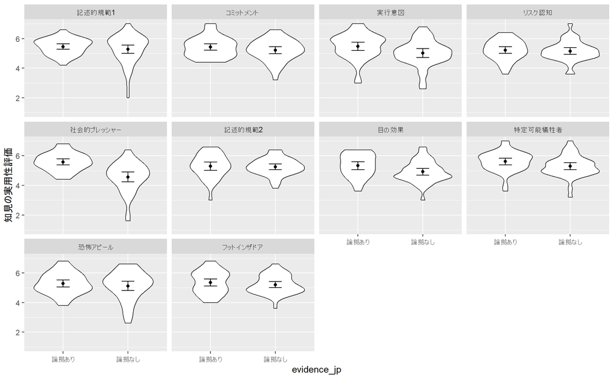

### 知見の重要性評価

#### 2-way ANOVA: Evidence x Theme

| theme_jp | evidence_jp | n | Mean | SD | SE | CI95 | CI95_L | CI95_U |
| --- | --- | --- | --- | --- | --- | --- | --- | --- |
| 記述的規範1 | 論拠あり | 37 | 5.17 | 0.602 | 0.099 | 0.201 | 4.97 | 5.37 |
| 記述的規範1 | 論拠なし | 49 | 4.97 | 1.129 | 0.161 | 0.324 | 4.64 | 5.29 |
| コミットメント | 論拠あり | 41 | 5.22 | 0.915 | 0.143 | 0.289 | 4.93 | 5.51 |
| コミットメント | 論拠なし | 39 | 5.05 | 1.007 | 0.161 | 0.327 | 4.72 | 5.38 |
| 実行意図 | 論拠あり | 39 | 5.15 | 1.169 | 0.187 | 0.379 | 4.78 | 5.53 |
| 実行意図 | 論拠なし | 36 | 4.67 | 0.915 | 0.153 | 0.310 | 4.36 | 4.98 |
| リスク認知 | 論拠あり | 39 | 5.45 | 0.863 | 0.138 | 0.280 | 5.17 | 5.73 |
| リスク認知 | 論拠なし | 38 | 5.61 | 0.859 | 0.139 | 0.282 | 5.32 | 5.89 |
| 社会的プレッシャー | 論拠あり | 36 | 5.20 | 1.043 | 0.174 | 0.353 | 4.85 | 5.56 |
| 社会的プレッシャー | 論拠なし | 37 | 4.30 | 1.227 | 0.202 | 0.409 | 3.89 | 4.71 |
| 記述的規範2 | 論拠あり | 34 | 5.07 | 0.984 | 0.169 | 0.343 | 4.72 | 5.41 |
| 記述的規範2 | 論拠なし | 38 | 4.58 | 1.128 | 0.183 | 0.371 | 4.21 | 4.95 |
| 目の効果 | 論拠あり | 34 | 4.98 | 0.868 | 0.149 | 0.303 | 4.68 | 5.28 |
| 目の効果 | 論拠なし | 40 | 4.38 | 0.985 | 0.156 | 0.315 | 4.06 | 4.69 |
| 特定可能犠牲者 | 論拠あり | 39 | 5.36 | 0.913 | 0.146 | 0.296 | 5.06 | 5.66 |
| 特定可能犠牲者 | 論拠なし | 39 | 5.21 | 0.996 | 0.159 | 0.323 | 4.88 | 5.53 |
| 恐怖アピール | 論拠あり | 37 | 5.33 | 0.853 | 0.140 | 0.285 | 5.05 | 5.62 |
| 恐怖アピール | 論拠なし | 42 | 5.13 | 1.097 | 0.169 | 0.342 | 4.79 | 5.47 |
| フットインザドア | 論拠あり | 40 | 4.90 | 0.771 | 0.122 | 0.246 | 4.65 | 5.15 |
| フットインザドア | 論拠なし | 39 | 4.82 | 0.844 | 0.135 | 0.274 | 4.55 | 5.09 |

source.col

ss.col

df.col

ms.col

f.col

p.col

sig.col

p.eta^2

Theme

49.5

9

5.503

5.82

0.000

***

0.065

Evidence

19.1

1

19.055

20.15

0.000

***

0.026

Theme x Evidence

15.7

9

1.749

1.85

0.056

0.022

Error

712.2

753

0.946

Total

797.1

772

1.033

Posthoc analysis: Simple effects for Evidence x Theme interaction

source.col

ss.col

df.col

ms.col

f.col

p.col

sig.col

p.eta^2

Theme at 論拠あり

10.033

9

1.115

1.179

0.305

ns

0.014

Theme at 論拠なし

56.157

9

6.240

6.597

0.000

***

0.073

Evidence at 記述的規範1

0.888

1

0.888

0.938

0.333

ns

0.001

Evidence at コミットメント

0.566

1

0.566

0.598

0.440

ns

0.001

Evidence at 実行意図

4.443

1

4.443

4.698

0.031

0.006

Evidence at リスク認知

0.446

1

0.446

0.472

0.492

ns

0.001

Evidence at 社会的プレッシャー

14.991

1

14.991

15.850

0.000

***

0.021

Evidence at 記述的規範2

4.303

1

4.303

4.549

0.033

0.006

Evidence at 目の効果

6.736

1

6.736

7.122

0.008

0.009

Evidence at 特定犠牲者

0.462

1

0.462

0.488

0.485

ns

0.001

Evidence at 恐怖アピール

0.838

1

0.838

0.886

0.347

ns

0.001

Evidence at フットインザドア

0.125

1

0.125

0.132

0.717

ns

0.000

Error

712.190

753

0.946

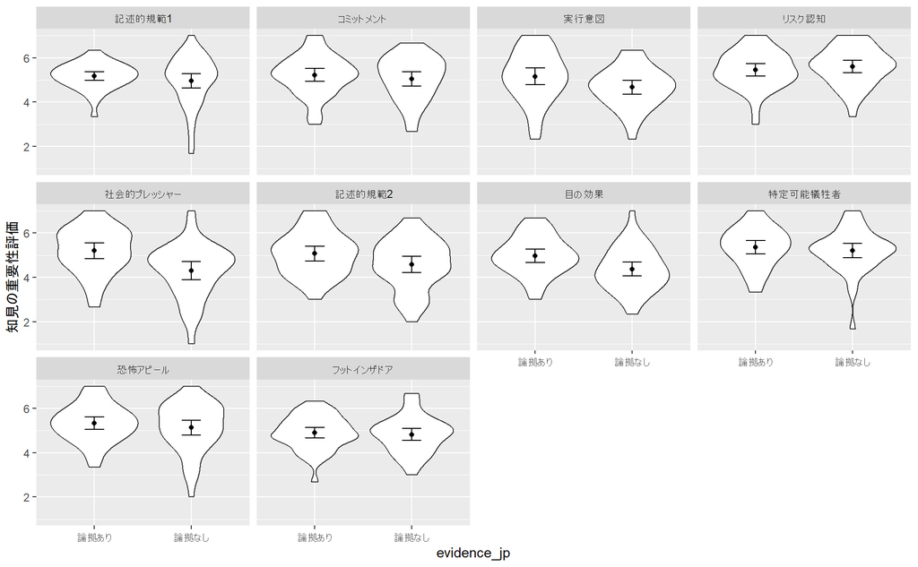

### 取り組みへのポジティブ認知

#### 2-way ANOVA: Evidence x Theme

| theme_jp | evidence_jp | n | Mean | SD | SE | CI95 | CI95_L | CI95_U |
| --- | --- | --- | --- | --- | --- | --- | --- | --- |
| 記述的規範1 | 論拠あり | 37 | 4.79 | 0.673 | 0.111 | 0.224 | 4.57 | 5.01 |
| 記述的規範1 | 論拠なし | 49 | 4.82 | 0.973 | 0.139 | 0.280 | 4.54 | 5.10 |
| コミットメント | 論拠あり | 41 | 4.84 | 0.682 | 0.106 | 0.215 | 4.63 | 5.06 |
| コミットメント | 論拠なし | 39 | 4.88 | 1.035 | 0.166 | 0.336 | 4.55 | 5.22 |
| 実行意図 | 論拠あり | 39 | 4.88 | 0.839 | 0.134 | 0.272 | 4.61 | 5.16 |
| 実行意図 | 論拠なし | 36 | 4.46 | 0.822 | 0.137 | 0.278 | 4.19 | 4.74 |
| リスク認知 | 論拠あり | 39 | 5.13 | 0.761 | 0.122 | 0.247 | 4.88 | 5.38 |
| リスク認知 | 論拠なし | 38 | 5.10 | 0.894 | 0.145 | 0.294 | 4.80 | 5.39 |
| 社会的プレッシャー | 論拠あり | 36 | 4.42 | 1.000 | 0.167 | 0.338 | 4.08 | 4.75 |
| 社会的プレッシャー | 論拠なし | 37 | 3.85 | 0.940 | 0.154 | 0.313 | 3.53 | 4.16 |
| 記述的規範2 | 論拠あり | 34 | 4.90 | 1.082 | 0.186 | 0.378 | 4.52 | 5.28 |
| 記述的規範2 | 論拠なし | 38 | 4.61 | 0.942 | 0.153 | 0.310 | 4.30 | 4.92 |
| 目の効果 | 論拠あり | 34 | 4.76 | 0.821 | 0.141 | 0.286 | 4.48 | 5.05 |
| 目の効果 | 論拠なし | 40 | 4.21 | 0.752 | 0.119 | 0.241 | 3.97 | 4.45 |
| 特定可能犠牲者 | 論拠あり | 39 | 4.83 | 0.662 | 0.106 | 0.215 | 4.61 | 5.04 |
| 特定可能犠牲者 | 論拠なし | 39 | 4.92 | 0.710 | 0.114 | 0.230 | 4.69 | 5.15 |
| 恐怖アピール | 論拠あり | 37 | 5.02 | 0.670 | 0.110 | 0.223 | 4.80 | 5.24 |
| 恐怖アピール | 論拠なし | 42 | 4.61 | 1.107 | 0.171 | 0.345 | 4.26 | 4.95 |
| フットインザドア | 論拠あり | 40 | 4.47 | 0.909 | 0.144 | 0.291 | 4.18 | 4.77 |
| フットインザドア | 論拠なし | 39 | 4.19 | 0.706 | 0.113 | 0.229 | 3.96 | 4.42 |

source.col

ss.col

df.col

ms.col

f.col

p.col

sig.col

p.eta^2

Theme

57.3

9

6.369

8.58

0.000

***

0.093

Evidence

11.0

1

10.965

14.77

0.000

***

0.019

Theme x Evidence

11.2

9

1.245

1.68

0.091

0.020

Error

559.0

753

0.742

Total

638.5

772

0.827

Posthoc analysis: Simple effects for Evidence x Theme interaction

source.col

ss.col

df.col

ms.col

f.col

p.col

sig.col

p.eta^2

Theme at 論拠あり

16.245

9

1.805

2.431

0.010

0.028

Theme at 論拠なし

52.974

9

5.886

7.929

0.000

***

0.087

Evidence at 記述的規範1

0.014

1

0.014

0.019

0.891

ns

0.000

Evidence at コミットメント

0.037

1

0.037

0.050

0.823

ns

0.000

Evidence at 実行意図

3.292

1

3.292

4.434

0.036

0.006

Evidence at リスク認知

0.017

1

0.017

0.023

0.881

ns

0.000

Evidence at 社会的プレッシャー

5.971

1

5.971

8.044

0.005

0.011

Evidence at 記述的規範2

1.460

1

1.460

1.966

0.161

ns

0.003

Evidence at 目の効果

5.604

1

5.604

7.549

0.006

0.010

Evidence at 特定犠牲者

0.180

1

0.180

0.243

0.622

ns

0.000

Evidence at 恐怖アピール

3.357

1

3.357

4.522

0.034

0.006

Evidence at フットインザドア

1.578

1

1.578

2.126

0.145

ns

0.003

Error

559.006

753

0.742

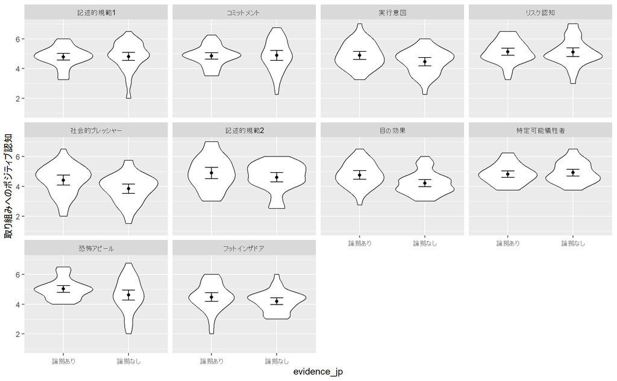

### 取り組みへのリスク認知

#### 2-way ANOVA: Evidence x Theme

| theme_jp | evidence_jp | n | Mean | SD | SE | CI95 | CI95_L | CI95_U |
| --- | --- | --- | --- | --- | --- | --- | --- | --- |
| 記述的規範1 | 論拠あり | 37 | 3.93 | 0.943 | 0.155 | 0.314 | 3.62 | 4.25 |
| 記述的規範1 | 論拠なし | 49 | 3.71 | 0.962 | 0.137 | 0.276 | 3.44 | 3.99 |
| コミットメント | 論拠あり | 41 | 3.85 | 1.073 | 0.168 | 0.339 | 3.51 | 4.18 |
| コミットメント | 論拠なし | 39 | 3.47 | 1.164 | 0.186 | 0.377 | 3.10 | 3.85 |
| 実行意図 | 論拠あり | 39 | 3.91 | 1.143 | 0.183 | 0.371 | 3.54 | 4.28 |
| 実行意図 | 論拠なし | 36 | 4.25 | 1.072 | 0.179 | 0.363 | 3.88 | 4.61 |
| リスク認知 | 論拠あり | 39 | 3.04 | 1.080 | 0.173 | 0.350 | 2.69 | 3.39 |
| リスク認知 | 論拠なし | 38 | 2.98 | 1.001 | 0.162 | 0.329 | 2.65 | 3.31 |
| 社会的プレッシャー | 論拠あり | 36 | 4.93 | 1.250 | 0.208 | 0.423 | 4.51 | 5.35 |
| 社会的プレッシャー | 論拠なし | 37 | 5.41 | 0.735 | 0.121 | 0.245 | 5.16 | 5.66 |
| 記述的規範2 | 論拠あり | 34 | 3.79 | 1.302 | 0.223 | 0.454 | 3.34 | 4.25 |
| 記述的規範2 | 論拠なし | 38 | 3.81 | 1.265 | 0.205 | 0.416 | 3.40 | 4.23 |
| 目の効果 | 論拠あり | 34 | 4.00 | 0.945 | 0.162 | 0.330 | 3.67 | 4.33 |
| 目の効果 | 論拠なし | 40 | 4.57 | 1.021 | 0.161 | 0.327 | 4.24 | 4.89 |
| 特定可能犠牲者 | 論拠あり | 39 | 4.36 | 1.035 | 0.166 | 0.335 | 4.02 | 4.69 |
| 特定可能犠牲者 | 論拠なし | 39 | 4.02 | 0.781 | 0.125 | 0.253 | 3.76 | 4.27 |
| 恐怖アピール | 論拠あり | 37 | 3.74 | 0.995 | 0.164 | 0.332 | 3.41 | 4.07 |
| 恐怖アピール | 論拠なし | 42 | 4.36 | 1.196 | 0.184 | 0.373 | 3.99 | 4.73 |
| フットインザドア | 論拠あり | 40 | 4.38 | 0.999 | 0.158 | 0.319 | 4.06 | 4.70 |
| フットインザドア | 論拠なし | 39 | 4.44 | 0.948 | 0.152 | 0.307 | 4.14 | 4.75 |

source.col

ss.col

df.col

ms.col

f.col

p.col

sig.col

p.eta^2

Theme

211.43

9

23.49

21.17

0.000

***

0.202

Evidence

2.34

1

2.34

2.11

0.147

ns

0.003

Theme x Evidence

23.95

9

2.66

2.40

0.011

0.028

Error

835.65

753

1.11

Total

1074.83

772

1.39

Posthoc analysis: Simple effects for Evidence x Theme interaction

source.col

ss.col

df.col

ms.col

f.col

p.col

sig.col

p.eta^2

Theme at 論拠あり

83.274

9

9.253

8.338

0.000

***

0.091

Theme at 論拠なし

153.871

9

17.097

15.406

0.000

***

0.155

Evidence at 記述的規範1

1.003

1

1.003

0.904

0.342

ns

0.001

Evidence at コミットメント

2.754

1

2.754

2.481

0.116

ns

0.003

Evidence at 実行意図

2.102

1

2.102

1.894

0.169

ns

0.003

Evidence at リスク認知

0.060

1

0.060

0.054

0.816

ns

0.000

Evidence at 社会的プレッシャー

4.193

1

4.193

3.778

0.052

0.005

Evidence at 記述的規範2

0.005

1

0.005

0.005

0.945

ns

0.000

Evidence at 目の効果

5.902

1

5.902

5.318

0.021

0.007

Evidence at 特定犠牲者

2.223

1

2.223

2.003

0.157

ns

0.003

Evidence at 恐怖アピール

7.619

1

7.619

6.866

0.009

0.009

Evidence at フットインザドア

0.084

1

0.084

0.076

0.783

ns

0.000

Error

835.651

753

1.110

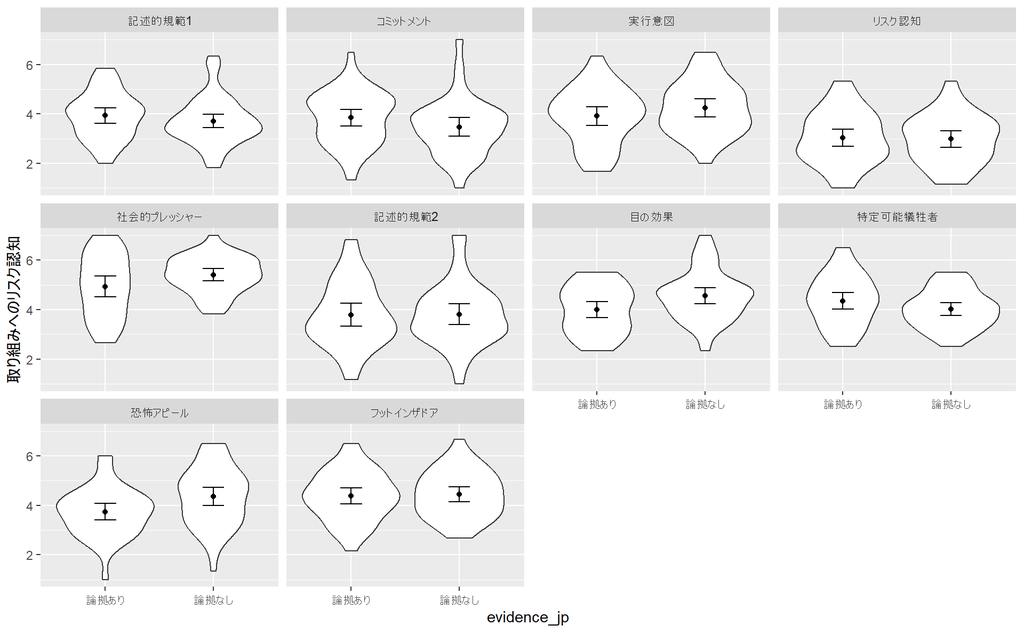

### 取り組みへの賛否

#### 2-way ANOVA: Evidence x Theme

| theme_jp | evidence_jp | n | Mean | SD | SE | CI95 | CI95_L | CI95_U |
| --- | --- | --- | --- | --- | --- | --- | --- | --- |
| 記述的規範1 | 論拠あり | 37 | 5.49 | 2.24 | 0.369 | 0.748 | 4.74 | 6.24 |
| 記述的規範1 | 論拠なし | 49 | 5.65 | 2.10 | 0.300 | 0.602 | 5.05 | 6.25 |
| コミットメント | 論拠あり | 41 | 5.58 | 2.14 | 0.335 | 0.677 | 4.91 | 6.26 |
| コミットメント | 論拠なし | 39 | 5.87 | 2.34 | 0.375 | 0.759 | 5.11 | 6.63 |
| 実行意図 | 論拠あり | 39 | 6.38 | 1.83 | 0.293 | 0.593 | 5.79 | 6.98 |
| 実行意図 | 論拠なし | 36 | 4.83 | 2.56 | 0.426 | 0.865 | 3.97 | 5.70 |
| リスク認知 | 論拠あり | 39 | 7.03 | 1.65 | 0.264 | 0.534 | 6.49 | 7.56 |
| リスク認知 | 論拠なし | 38 | 6.58 | 2.15 | 0.349 | 0.707 | 5.87 | 7.29 |
| 社会的プレッシャー | 論拠あり | 36 | 3.97 | 2.72 | 0.453 | 0.920 | 3.05 | 4.89 |
| 社会的プレッシャー | 論拠なし | 37 | 2.70 | 2.31 | 0.379 | 0.769 | 1.93 | 3.47 |
| 記述的規範2 | 論拠あり | 34 | 5.68 | 2.48 | 0.426 | 0.866 | 4.81 | 6.54 |
| 記述的規範2 | 論拠なし | 38 | 5.66 | 2.50 | 0.405 | 0.820 | 4.84 | 6.48 |
| 目の効果 | 論拠あり | 34 | 6.03 | 1.98 | 0.339 | 0.690 | 5.34 | 6.72 |
| 目の効果 | 論拠なし | 40 | 3.92 | 2.19 | 0.346 | 0.700 | 3.23 | 4.62 |
| 特定可能犠牲者 | 論拠あり | 39 | 4.97 | 2.28 | 0.365 | 0.738 | 4.24 | 5.71 |
| 特定可能犠牲者 | 論拠なし | 39 | 6.33 | 1.69 | 0.271 | 0.548 | 5.79 | 6.88 |
| 恐怖アピール | 論拠あり | 37 | 6.11 | 1.84 | 0.302 | 0.613 | 5.50 | 6.72 |
| 恐怖アピール | 論拠なし | 42 | 5.21 | 2.37 | 0.366 | 0.740 | 4.47 | 5.95 |
| フットインザドア | 論拠あり | 40 | 5.03 | 1.94 | 0.307 | 0.621 | 4.40 | 5.65 |
| フットインザドア | 論拠なし | 39 | 4.85 | 2.25 | 0.361 | 0.731 | 4.12 | 5.58 |

| source.col | ss.col | df.col | ms.col | f.col | p.col | sig.col | p.eta^2 |
| --- | --- | --- | --- | --- | --- | --- | --- |
| Theme | 521.9 | 9 | 57.98 | 12.08 | 0.000 | *** | 0.126 |
| Evidence | 41.6 | 1 | 41.56 | 8.66 | 0.003 | ** | 0.011 |
| Theme x Evidence | 176.6 | 9 | 19.62 | 4.09 | 0.000 | *** | 0.047 |
| Error | 3613.9 | 753 | 4.80 |  |  |  |  |
| Total | 4359.5 | 772 | 5.65 |  |  |  |  |

Posthoc analysis: Simple effects for Evidence x Theme interaction

source.col

ss.col

df.col

ms.col

f.col

p.col

sig.col

p.eta^2

Theme at 論拠あり

243.314

9

27.035

5.633

0.000

***

0.063

Theme at 論拠なし

463.346

9

51.483

10.727

0.000

***

0.114

Evidence at 記述的規範1

0.585

1

0.585

0.122

0.727

ns

0.000

Evidence at コミットメント

1.640

1

1.640

0.342

0.559

ns

0.000

Evidence at 実行意図

45.049

1

45.049

9.387

0.002

0.012

Evidence at リスク認知

3.840

1

3.840

0.800

0.371

ns

0.001

Evidence at 社会的プレッシャー

29.408

1

29.408

6.127

0.014

0.008

Evidence at 記述的規範2

0.006

1

0.006

0.001

0.971

ns

0.000

Evidence at 目の効果

81.390

1

81.390

16.959

0.000

***

0.022

Evidence at 特定犠牲者

36.013

1

36.013

7.504

0.006

0.010

Evidence at 恐怖アピール

15.715

1

15.715

3.275

0.071

0.004

Evidence at フットインザドア

0.632

1

0.632

0.132

0.717

ns

0.000

Error

3613.897

753

4.799

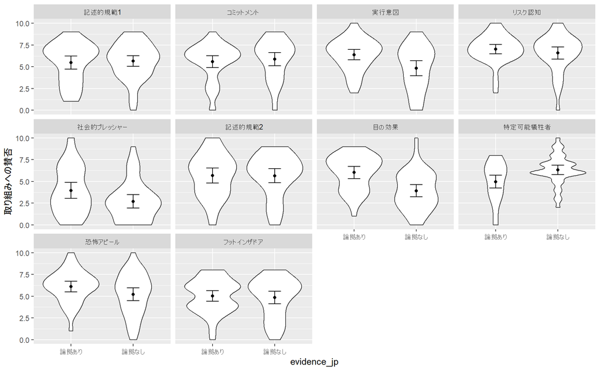

### EBPMへの一般的態度

#### 2-way ANOVA: Evidence x Theme

| theme_jp | evidence_jp | n | Mean | SD | SE | CI95 | CI95_L | CI95_U |
| --- | --- | --- | --- | --- | --- | --- | --- | --- |
| 記述的規範1 | 論拠あり | 37 | 5.37 | 1.052 | 0.173 | 0.351 | 5.01 | 5.72 |
| 記述的規範1 | 論拠なし | 49 | 5.50 | 0.946 | 0.135 | 0.272 | 5.23 | 5.77 |
| コミットメント | 論拠あり | 41 | 5.51 | 0.918 | 0.143 | 0.290 | 5.22 | 5.80 |
| コミットメント | 論拠なし | 39 | 5.54 | 0.884 | 0.142 | 0.287 | 5.25 | 5.83 |
| 実行意図 | 論拠あり | 39 | 5.60 | 1.182 | 0.189 | 0.383 | 5.22 | 5.99 |
| 実行意図 | 論拠なし | 36 | 5.62 | 0.897 | 0.150 | 0.304 | 5.32 | 5.93 |
| リスク認知 | 論拠あり | 39 | 5.42 | 0.815 | 0.131 | 0.264 | 5.16 | 5.69 |
| リスク認知 | 論拠なし | 38 | 5.46 | 0.933 | 0.151 | 0.307 | 5.15 | 5.77 |
| 社会的プレッシャー | 論拠あり | 36 | 5.21 | 1.441 | 0.240 | 0.488 | 4.72 | 5.70 |
| 社会的プレッシャー | 論拠なし | 37 | 4.99 | 0.932 | 0.153 | 0.311 | 4.68 | 5.30 |
| 記述的規範2 | 論拠あり | 34 | 5.66 | 0.766 | 0.131 | 0.267 | 5.39 | 5.93 |
| 記述的規範2 | 論拠なし | 38 | 5.89 | 0.679 | 0.110 | 0.223 | 5.67 | 6.12 |
| 目の効果 | 論拠あり | 34 | 5.50 | 1.015 | 0.174 | 0.354 | 5.15 | 5.85 |
| 目の効果 | 論拠なし | 40 | 5.44 | 0.962 | 0.152 | 0.308 | 5.13 | 5.75 |
| 特定可能犠牲者 | 論拠あり | 39 | 5.55 | 0.667 | 0.107 | 0.216 | 5.33 | 5.77 |
| 特定可能犠牲者 | 論拠なし | 39 | 5.60 | 0.804 | 0.129 | 0.261 | 5.34 | 5.86 |
| 恐怖アピール | 論拠あり | 37 | 5.43 | 0.891 | 0.146 | 0.297 | 5.13 | 5.73 |
| 恐怖アピール | 論拠なし | 42 | 5.91 | 0.892 | 0.138 | 0.278 | 5.63 | 6.18 |
| フットインザドア | 論拠あり | 40 | 5.40 | 0.907 | 0.143 | 0.290 | 5.11 | 5.69 |
| フットインザドア | 論拠なし | 39 | 5.35 | 1.046 | 0.167 | 0.339 | 5.01 | 5.68 |

| source.col | ss.col | df.col | ms.col | f.col | p.col | sig.col | p.eta^2 |
| --- | --- | --- | --- | --- | --- | --- | --- |
| Theme | 23.090 | 9 | 2.566 | 2.876 | 0.002 | ** | 0.033 |
| Evidence | 0.786 | 1 | 0.786 | 0.881 | 0.348 | ns | 0.001 |
| Theme x Evidence | 6.035 | 9 | 0.671 | 0.752 | 0.662 | ns | 0.009 |
| Error | 671.826 | 753 | 0.892 |  |  |  |  |
| Total | 702.500 | 772 | 0.910 |  |  |  |  |

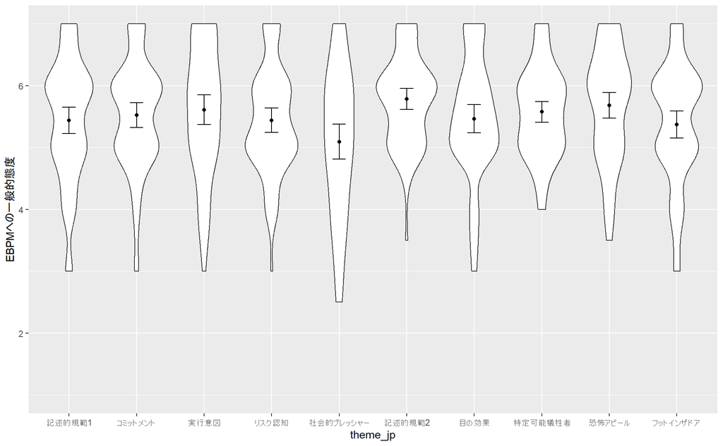

### 政府・研究者への信頼

| target | n | Mean | SD | SE | CI95 | CI95_L | CI95_U |
| --- | --- | --- | --- | --- | --- | --- | --- |
| comp_gvt | 773 | 3.60 | 1.291 | 0.046 | 0.091 | 3.50 | 3.69 |
| comp_rsch | 773 | 5.57 | 0.959 | 0.034 | 0.068 | 5.50 | 5.64 |
| fair_gvt | 773 | 3.48 | 1.233 | 0.044 | 0.087 | 3.39 | 3.57 |
| fair_rsch | 773 | 5.14 | 0.879 | 0.032 | 0.062 | 5.08 | 5.21 |
| trst_gvt | 773 | 3.28 | 1.220 | 0.044 | 0.086 | 3.19 | 3.37 |
| trst_rsch | 773 | 5.04 | 1.008 | 0.036 | 0.071 | 4.97 | 5.12 |
| valu_gvt | 773 | 3.32 | 1.154 | 0.042 | 0.081 | 3.24 | 3.40 |
| valu_rsch | 773 | 4.16 | 1.073 | 0.039 | 0.076 | 4.09 | 4.24 |

### 社会科学への態度

#### 科学性の認知

| domain | n | Mean | SD | SE | CI95 | CI95_L | CI95_U |
| --- | --- | --- | --- | --- | --- | --- | --- |
| sci_econ | 773 | 4.46 | 1.01 | 0.036 | 0.071 | 4.39 | 4.53 |
| sci_poli | 773 | 4.30 | 1.08 | 0.039 | 0.076 | 4.22 | 4.38 |
| sci_psyc | 773 | 4.53 | 1.03 | 0.037 | 0.073 | 4.45 | 4.60 |

| source.col | ss.col | df.col | ms.col | f.col | p.col | sig.col | p.eta^2 |
| --- | --- | --- | --- | --- | --- | --- | --- |
| Theme | 11.935 | 9 | 1.326 | 0.641 | 0.763 | ns | 0.008 |
| Evidence | 0.003 | 1 | 0.003 | 0.002 | 0.968 | ns | 0.000 |
| Theme x Evidence | 10.926 | 9 | 1.214 | 0.586 | 0.809 | ns | 0.007 |
| s x Theme x Evidence | 1558.910 | 753 | 2.070 |  |  |  |  |
| Domain | 20.848 | 2 | 10.424 | 17.377 | 0.000 | *** | 0.023 |
| Theme x Domain | 14.463 | 18 | 0.803 | 1.339 | 0.154 | ns | 0.016 |
| Evidence x Domain | 0.893 | 2 | 0.447 | 0.745 | 0.475 | ns | 0.001 |
| Theme x Evidence x Domain | 7.949 | 18 | 0.442 | 0.736 | 0.776 | ns | 0.009 |
| s x Theme x Evidence x Domain | 903.384 | 1506 | 0.600 |  |  |  |  |
| Total | 2529.723 | 2318 | 1.091 |  |  |  |  |

|  | pair | difference | t | df | p.value | adj.p | significance |
| --- | --- | --- | --- | --- | --- | --- | --- |
| 2 | 社会心理-政策科学 | 0.227 | 5.33 | 753 | 0.000 | 0.000 | 社会心理 > 政策科学 * |
| 3 | 行動経済学-政策科学 | 0.159 | 3.82 | 753 | 0.000 | 0.000 | 行動経済学 > 政策科学 * |
| 1 | 社会心理-行動経済学 | 0.068 | 2.01 | 753 | 0.045 | 0.045 | 社会心理 > 行動経済学 * |

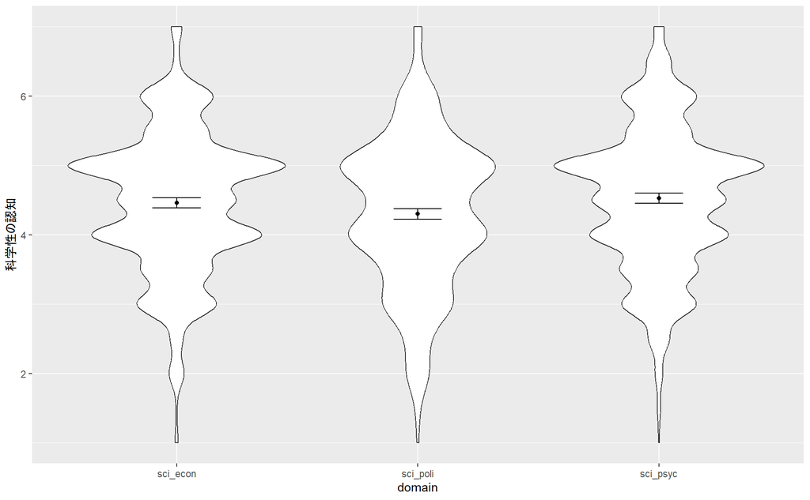

#### ポジティブ認知

| domain | n | Mean | SD | SE | CI95 | CI95_L | CI95_U |
| --- | --- | --- | --- | --- | --- | --- | --- |
| pos_econ | 773 | 4.64 | 0.747 | 0.027 | 0.053 | 4.59 | 4.69 |
| pos_poli | 773 | 4.34 | 0.793 | 0.029 | 0.056 | 4.29 | 4.40 |
| pos_psyc | 773 | 4.65 | 0.749 | 0.027 | 0.053 | 4.60 | 4.70 |

source.col

ss.col

df.col

ms.col

f.col

p.col

sig.col

p.eta^2

Theme

10.569

9

1.174

0.910

0.516

ns

0.011

Evidence

0.966

1

0.966

0.749

0.387

ns

0.001

Theme x Evidence

9.499

9

1.055

0.818

0.600

ns

0.010

s x Theme x Evidence

971.958

753

1.291

Domain

46.772

2

23.386

100.705

0.000

***

0.118

Theme x Domain

2.594

18

0.144

0.621

0.886

ns

0.007

Evidence x Domain

1.170

2

0.585

2.520

0.081

0.003

Theme x Evidence x Domain

2.330

18

0.129

0.557

0.930

ns

0.007

s x Theme x Evidence x Domain

349.725

1506

0.232

Total

1395.815

2318

0.602

|  | pair | difference | t | df | p.value | adj.p | significance |
| --- | --- | --- | --- | --- | --- | --- | --- |
| 2 | 社会心理-政策科学 | 0.308 | 11.792 | 753 | 0.000 | 0.000 | 社会心理 > 政策科学 * |
| 3 | 行動経済学-政策科学 | 0.296 | 11.098 | 753 | 0.000 | 0.000 | 行動経済学 > 政策科学 * |
| 1 | 社会心理-行動経済学 | 0.011 | 0.541 | 753 | 0.588 | 0.588 | 社会心理 = 行動経済学 |

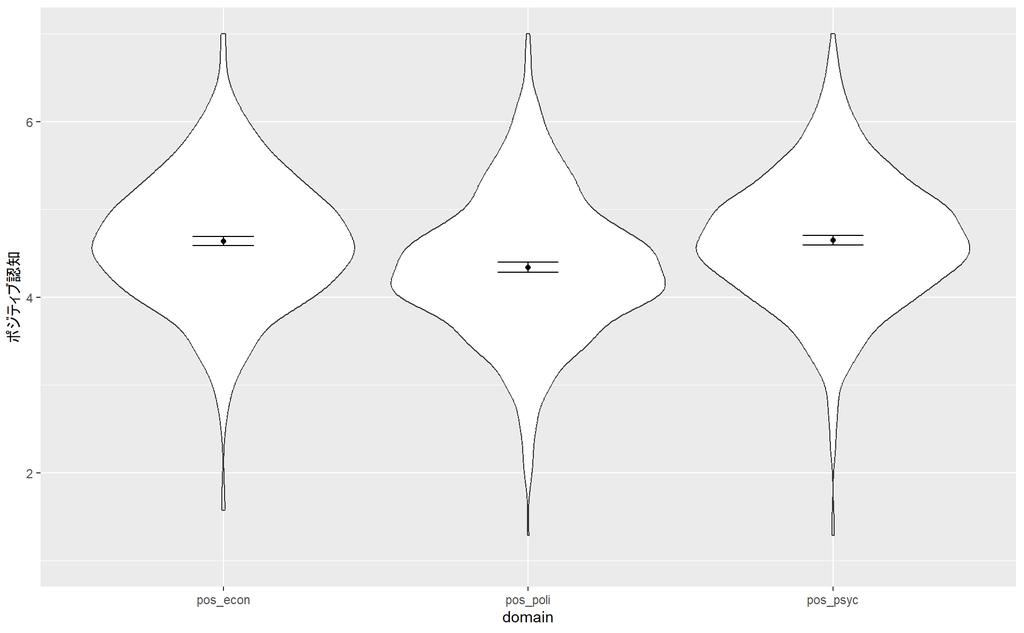

### クラスター分析

10種類あるテーマを特徴にもとづいて分類するため、クラスター分析を行った。  
分類には、実用性と重要性の8項目のテーマごとの平均値を用いた。

デンドログラムから４クラスターでの解釈可能性の高さが示唆された。また、妥当性指標も４クラスターが示唆された。

#### 階層的クラスター分析（ウォード法、デンドログラム）

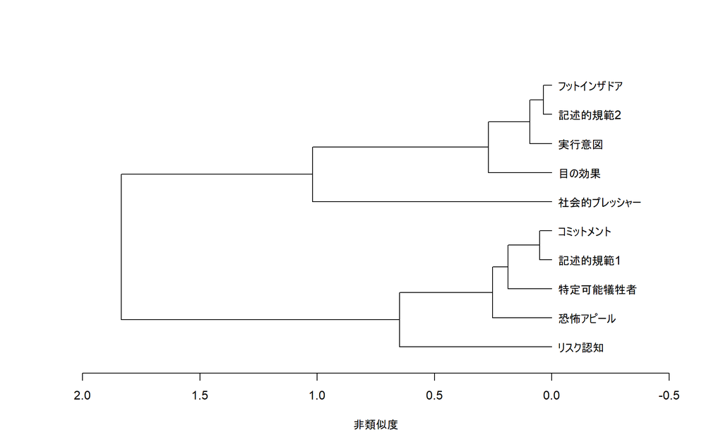

#### 非階層的クラスター分析（k平均法）

##### クラスター数の妥当性の確認

CH: Calinski & Harabasz (1974), diffH: Hartigan (1975), KL: Krzanowski & Lai (1988)  
*greater values indicate better fit

| cluster.n | CH | H | diffH | KL |
| --- | --- | --- | --- | --- |
| 2 | 5.74 | 4.84 | 0.900 | 1.285 |
| 3 | 6.67 | 4.20 | 0.647 | 1.438 |
| 4 | 7.88 | 1.97 | 2.225 | 2.407 |
| 5 | 7.36 | 2.93 | -0.959 | 0.804 |
| 6 | 8.74 | 3.08 | -0.151 | 1.345 |
| 7 | 11.59 | 2.14 | 0.936 | 1.897 |
| 8 | 14.03 | 1.42 | 0.727 | 1.750 |

##### 各クラスターの平均値とプロット

|  | cluster |
| --- | --- |
| 記述的規範1 | 1 |
| コミットメント | 1 |
| 特定可能犠牲者 | 1 |
| 恐怖アピール | 1 |
| 実行意図 | 2 |
| 記述的規範2 | 2 |
| 目の効果 | 2 |
| フットインザドア | 2 |
| 社会的プレッシャー | 3 |
| リスク認知 | 4 |

| cluster | g1m | g2m | g3m | g4m | s1m | s2m | s3m | s4m |
| --- | --- | --- | --- | --- | --- | --- | --- | --- |
| 1 | 5.30 | 5.41 | 5.15 | 5.17 | 5.35 | 5.62 | 5.19 | 4.98 |
| 2 | 5.31 | 5.38 | 5.10 | 4.94 | 5.01 | 5.43 | 4.92 | 4.50 |
| 3 | 5.18 | 5.42 | 5.23 | 4.56 | 4.95 | 4.95 | 4.21 | 5.08 |
| 4 | 5.23 | 5.58 | 4.84 | 5.07 | 5.75 | 5.23 | 5.26 | 5.57 |

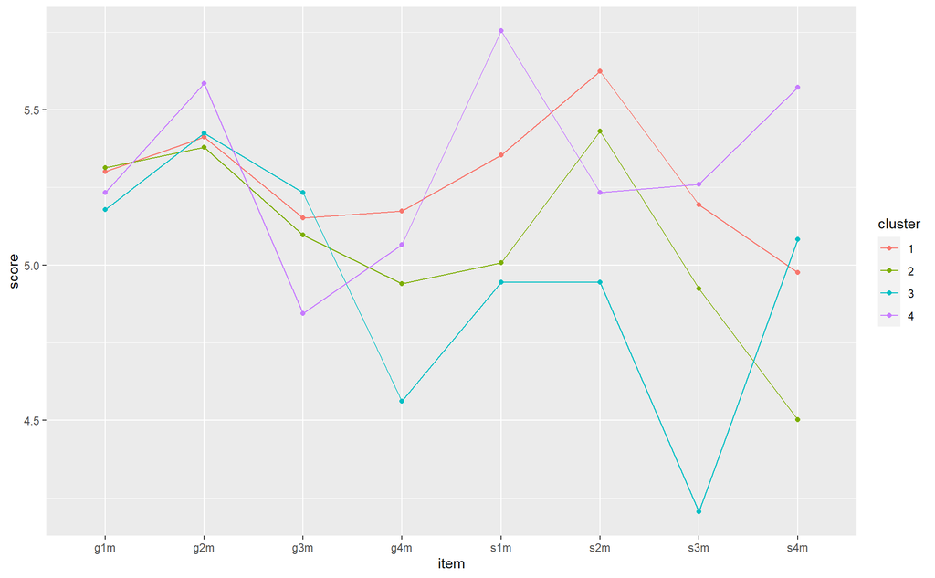